# Runs Test Paper

Lindesay Scott-Hayward

2016-07-19

# Simulated Data

Make some simulated toy data using the following equation:

$$y=\beta_0\ +\ \beta_1X_1$$

where $\beta_0 = 1$ and $\beta_1= 0.3$

```r
dat<-makeToyData(200, length.panels=5)
head(dat)
```

```
         x evph       mu panelid
1 1.000000    0 3.669297       1
2 1.090909    0 3.770746       1
3 1.181818    0 3.874999       1
4 1.272727    0 3.982135       1
5 1.363636    0 4.092234       1
6 1.454545    0 4.205376       2
```

## Uncorrelated data

1000 sets of noisy data are simulated from this truth using a Poisson distribution.

```r
newdat<-generateNoise(nsim, dat$mu, family='poisson', d=1)
```

To test, fit a glm to one of the sets of data.

```r
init_glm<-glm(newdat[,1] ~ x, data=dat, family='quasipoisson')
summary(init_glm)
```

```
Call:
glm(formula = newdat[, 1] ~ x, family = "quasipoisson", data = dat)

Deviance Residuals:
    Min       1Q   Median       3Q      Max
-3.1729  -0.7094  -0.0248   0.5512   2.9691

Coefficients:
            Estimate Std. Error t value Pr(>|t|)
(Intercept) 1.068773   0.054457   19.63   <2e-16 ***
x           0.286713   0.007146   40.12   <2e-16 ***
---
Signif. codes:  0 '***' 0.001 '**' 0.01 '*' 0.05 '.' 0.1 ' ' 1

(Dispersion parameter for quasipoisson family taken to be 0.9516709)

    Null deviance: 1979.60  on 199  degrees of freedom
Residual deviance:  192.89  on 198  degrees of freedom
AIC: NA

Number of Fisher Scoring iterations: 4
```

Models were fitted to all datasets generated above and the runs test was evaluated for each one. The distribution of the test statistics is returned. A plot is also produced, which shows the lower 2.5% and upper 97.5% critical values of the empirical distribution (red) and from the Normal ($N(0,1)$) distribution.

[output not shown]

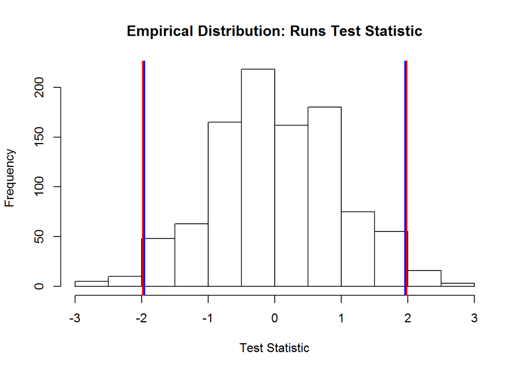

```r
empdistribution<-getRunsCritVals(n.sim = nsim, simData=newdat,
                                 model = init_glm, data = dat, plot=TRUE,
                                 returnDist = TRUE)
```

Use the data generated to assess the 5% error rate for this test when using the Normal distribition or the empirical distribution generated above.

```r
newdat<-generateNoise(nsim, dat$mu, family='poisson', d=1)
ps<-matrix(NA, nrow=nsim, ncol=2)

for(i in 1:nsim){
  sim_glm<-glm(newdat[,i] ~ x , data=dat, family='quasipoisson')
  # find both the empirical and Normal p-values
  ps[i,1]<-runs.test(residuals(sim_glm, type='pearson'), critvals = empdistribution)$p.value
  ps[i,2]<-runs.test(residuals(sim_glm, type='pearson'))$p.value
}
```

```r
(length(which(ps[,1]<0.05))/nsim)*100
```

```
[1] 4.6
```

```r
(length(which(ps[,2]<0.05))/nsim)*100
```

```
[1] 4.6
```

How does this change if we vary the dispersion parameter for the data?

```r
nphi=seq(1,51, by=5)
errrate<-matrix(NA, nrow=length(nphi), ncol=2)
counter=1
nsim=2000
for(p in nphi){
  newdat<-generateNoise(nsim, dat$mu, family='poisson', d=p)
  # for each change in phi, update the empirical distribution
  empdistribution<-getRunsCritVals(n.sim = nsim, simData=newdat,
                                   model = init_glm, data = dat, plot=FALSE,
                                   returnDist = TRUE, dots=FALSE)

  ps<-matrix(NA, nrow=nsim, ncol=2)
  for(i in 1:nsim){
    sim_glm<-glm(newdat[,i] ~ x + as.factor(evph), data=dat, family='quasipoisson')
    # find both the empirical and Normal p-values
    ps[i,1]<-runs.test(residuals(sim_glm, type='pearson'), critvals = empdistribution)$p.value
    ps[i,2]<-runs.test(residuals(sim_glm, type='pearson'))$p.value
  }

  errrate[counter,1]<-(length(which(ps[,1]<0.05))/nsim)*100
  errrate[counter,2]<-(length(which(ps[,2]<0.05))/nsim)*100
  counter=counter+1
}
```

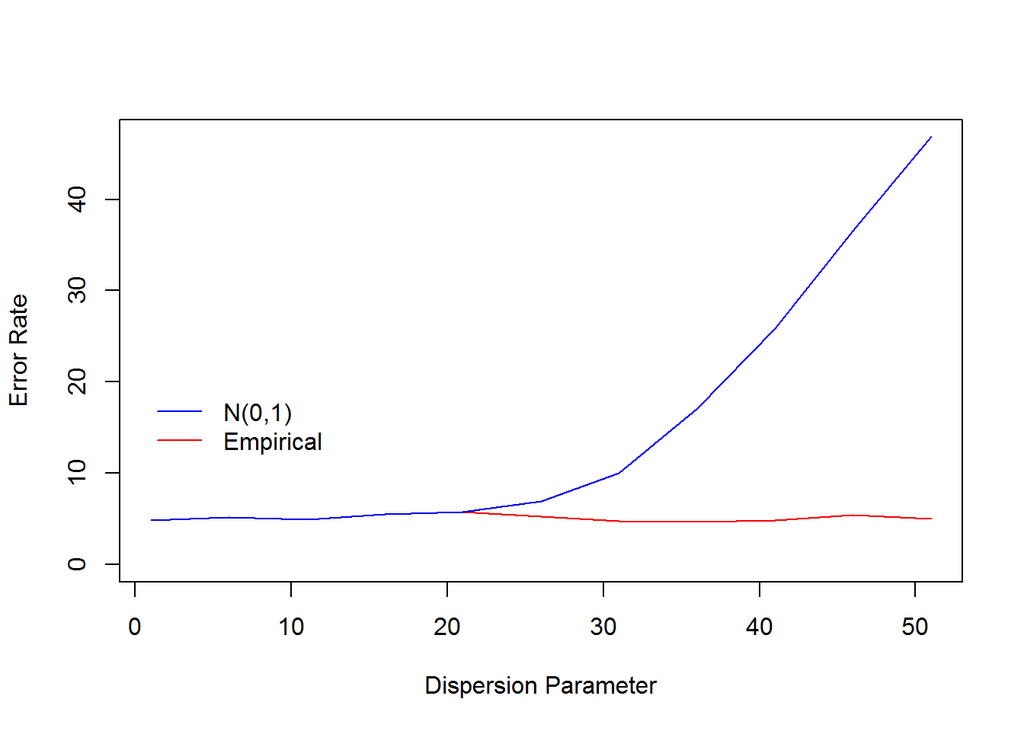

```r
plot(nphi, errrate[,1], type='l', col='red', ylim=c(0, range(errrate)[2]), ylab='Error Rate', xlab='Dispersion Parameter')
lines(nphi, errrate[,2], col='blue')
legend(0, 20, legend = c('N(0,1)', 'Empirical'), col = c('blue', 'red'), lty = c(1,1), bty = 'n')
```

## Correlated data

```r
dat<-makeToyData(200, length.panels=5)
head(dat)
```

```
         x evph       mu panelid
1 1.000000    0 3.669297       1
2 1.090909    0 3.770746       1
3 1.181818    0 3.874999       1
4 1.272727    0 3.982135       1
5 1.363636    0 4.092234       1
6 1.454545    0 4.205376       2
```

```r
nsim=2000
newdat<-generateNoise(nsim, dat$mu, family='poisson', d=1)
rho=seq(0.1, 0.9, by=0.1)
errrate<-matrix(NA, nrow=length(rho), ncol=2)
counter=1

for(r in rho){
  newdatcorr<-generateIC.toy(dat, c(1, r, r^2, r^3, r^4), 'panelid', newdat, ncol(newdat), dots=FALSE)

  # for each change in phi, update the empirical distribution
  empdistribution<-getRunsCritVals(n.sim = nsim, simData=newdat,
                                   model = init_glm, data = dat, plot=FALSE,
                                   returnDist = TRUE, dots=FALSE)

  ps<-matrix(NA, nrow=nsim, ncol=2)
  for(i in 1:nsim){
    sim_glm<-glm(newdatcorr[,i] ~ x , data=dat, family='quasipoisson')
    # find both the empirical and Normal p-values
    ps[i,1]<-runs.test(residuals(sim_glm, type='pearson'), critvals = empdistribution)$p.value
    ps[i,2]<-runs.test(residuals(sim_glm, type='pearson'))$p.value
  }

  errrate[counter,1]<-(length(which(ps[,1]<0.05))/nsim)*100
  errrate[counter,2]<-(length(which(ps[,2]<0.05))/nsim)*100
  counter=counter+1
}
```

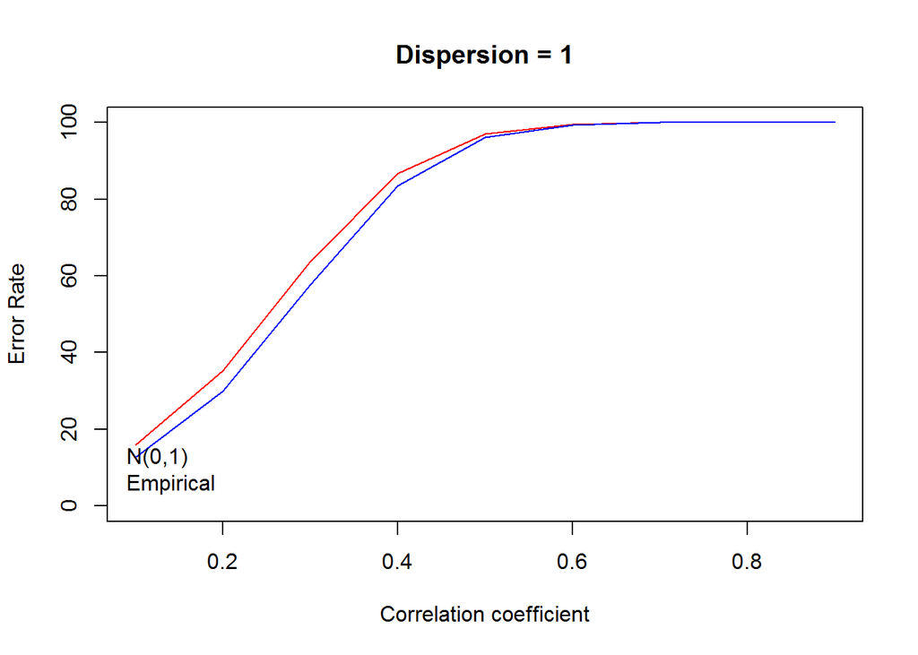

```r
plot(rho, errrate[,1], type='l', col='red', ylim=c(0, range(errrate)[2]), ylab='Error Rate', xlab='Correlation coefficient', main='Dispersion = 1')
lines(rho, errrate[,2], col='blue')
legend(0, 20, legend = c('N(0,1)', 'Empirical'), col = c('blue', 'red'), lty = c(1,1), bty = 'n')
```

## What does all this mean for power analysis?

If data are assumed to be correlated, then a correlation structure is chosen and GEE - type model fitted. If the independent working correlation structure is specified, then robust standard errors are used for inference. Does this machinery still work when there is actually no correlation present in the data?

Question:

1. Are robust standard errors the same as raw standard errors when no correlation is present?
2. What happens when a blocking structure is chosen that is not necessary. i.e. does the answer to question 1 vary with differing block structures?
3. Is the power to detect change affected by using robust standard errors when not necessary?

Make data but add an impact. Here we repeat the data but have a 50% decline in the response for the second set.

### 50% decline, $\phi = 50$

```r
datimp<-makeToyData(200, length.panels=5, changecoef.link = log(0.5))
head(datimp)
```

```
         x evph       mu panelid
1 1.000000    0 3.669297       1
2 1.090909    0 3.770746       1
3 1.181818    0 3.874999       1
4 1.272727    0 3.982135       1
5 1.363636    0 4.092234       1
6 1.454545    0 4.205376       2
```

Generate independent noisy data with a high dispersion, e.g. $\phi = 50$

```r
nsim=2000
newdat<-generateNoise(nsim, datimp$mu, family='poisson', d=50)
```

```r
init_impglm<-glm(newdat[,1] ~ x + as.factor(evph), data=datimp, family='quasipoisson')
summary(init_impglm)
```

```
Call:
glm(formula = newdat[, 1] ~ x + as.factor(evph), family = "quasipoisson",
    data = datimp)

Deviance Residuals:
     Min        1Q    Median        3Q       Max
-10.2630   -4.3301   -3.0328   -0.2332   30.3175

Coefficients:
                 Estimate Std. Error t value Pr(>|t|)
(Intercept)       1.44553    0.44357   3.259  0.00132 **
x                 0.26896    0.05758   4.671 5.55e-06 ***
as.factor(evph)1 -0.77559    0.28345  -2.736  0.00678 **
---
Signif. codes:  0 '***' 0.001 '**' 0.01 '*' 0.05 '.' 0.1 ' ' 1

(Dispersion parameter for quasipoisson family taken to be 59.85934)

    Null deviance: 7922.9  on 199  degrees of freedom
Residual deviance: 5943.2  on 197  degrees of freedom
AIC: NA

Number of Fisher Scoring iterations: 6
```

Get the empirical distribution critical values:

```r
empdistribution<-getRunsCritVals(n.sim = nsim, simData=newdat,
                                 model = init_impglm, data = datimp, plot=FALSE,
                                 returnDist = TRUE, dots=FALSE)
```

```r
runspowsim_out<-runsPowerSim(newdat, init_impglm, empdistribution, nsim, powercoefid = 3)
```

```r
apply(runspowsim_out$rawrob, 2, sum)/nsim
```

```
  Emp  Norm
0.063 0.841
```

```r
(length(which(runspowsim_out$imppvals[,1]<=0.05))/nsim)*100
```

```
[1] 73.6
```

```r
(length(which(runspowsim_out$imppvals[,2]<=0.05))/nsim)*100
```

```
[1] 74.3
```

### 25% decline, $\phi = 50$

```
   Emp   Norm
0.0665 0.6310
```

```
[1] 22.7
```

```
[1] 24.6
```

### 0% decline, $\phi = 50$

```
   Emp   Norm
0.0585 0.4560
```

```
[1] 5.3
```

```
[1] 5.55
```

It seems that when the Normal distribution is used to test for correlation, consistently the power to detect change is higher than when the empirical distribution is used to choose which standard errors to use.

Test: Repeat for 50% decline to get a range of power values. Check to see if the discrepancy is consistent.

### 50% decline, $\phi = 50$, multiruns

```r
wilcox.test(x = runspower[,1], runspower[,2], paired = T)
```

```
    Wilcoxon signed rank test with continuity correction

data:  runspower[, 1] and runspower[, 2]
V = 0, p-value < 2.2e-16
alternative hypothesis: true location shift is not equal to 0
```

```r
wilcox.test(x = power[,1], power[,2], paired = T)
```

```
    Wilcoxon signed rank test with continuity correction

data:  power[, 1] and power[, 2]
V = 4, p-value < 2.2e-16
alternative hypothesis: true location shift is not equal to 0
```

```r
apply(power, 2, mean)
```

```
[1] 72.9935 74.1575
```

```r
apply(runspower, 2, mean)
```

```
[1] 0.059480 0.834385
```

Statistically we have a significant difference between the power calculated from raw/robust s.e. but the real world significance in this toy example is minimal. The mean difference is one percentage point (with raw giving a higher power).

### 25% decline, $\phi = 50$, multiruns

```
    Wilcoxon signed rank test with continuity correction

data:  runspower[, 1] and runspower[, 2]
V = 0, p-value < 2.2e-16
alternative hypothesis: true location shift is not equal to 0
```

```
    Wilcoxon signed rank test with continuity correction

data:  power[, 1] and power[, 2]
V = 0, p-value < 2.2e-16
alternative hypothesis: true location shift is not equal to 0
```

```
[1] 23.5785 25.3245
```

```
[1] 0.058545 0.623260
```

# Real Data: Falls of Warness

```r
init_glm<-glm(response ~  TideState + WindStrength + SeaState + SimpPrecipitation + CloudCover, data=dat, family=quasipoisson)
```

```r
nsim=500
newdat<-generateNoise(nsim, fitted(init_glm), family='poisson', d=1)
```

500 sets of noisy data are simulated from this truth using a Poisson distribution.

To test, fit a glm to one of the sets of data.

```r
fowsim_glm<-glm(newdat[,1] ~  TideState + WindStrength + SeaState + SimpPrecipitation + CloudCover, data=dat, family=quasipoisson)
summary(fowsim_glm)
```

```
Call:
glm(formula = newdat[, 1] ~ TideState + WindStrength + SeaState +
    SimpPrecipitation + CloudCover, family = quasipoisson, data = dat)

Deviance Residuals:
    Min       1Q   Median       3Q      Max
-2.5931  -1.2262  -0.1338   0.5393   3.9499

Coefficients:
                          Estimate Std. Error t value Pr(>|t|)
(Intercept)              -0.707003   0.055574 -12.722  < 2e-16 ***
TideState                -0.119548   0.008540 -13.998  < 2e-16 ***
WindStrength             -0.342572   0.012356 -27.725  < 2e-16 ***
SeaState                  0.385857   0.012537  30.778  < 2e-16 ***
SimpPrecipitationHEAVY    0.006187   0.088535   0.070    0.944
SimpPrecipitationLIGHT    0.895789   0.052827  16.957  < 2e-16 ***
SimpPrecipitationNONE     0.307474   0.048548   6.333 2.44e-10 ***
SimpPrecipitationSHOWERS  0.805003   0.049119  16.389  < 2e-16 ***
CloudCover                0.095213   0.002927  32.534  < 2e-16 ***
---
Signif. codes:  0 '***' 0.001 '**' 0.01 '*' 0.05 '.' 0.1 ' ' 1

(Dispersion parameter for quasipoisson family taken to be 0.9921985)

    Null deviance: 34342  on 26334  degrees of freedom
Residual deviance: 29517  on 26326  degrees of freedom
AIC: NA

Number of Fisher Scoring iterations: 5
```

Models were fitted to all datasets generated above and the runs test was evaluated for each one. The distribution of the test statistics is returned. A plot is also produced, which shows the lower 2.5% and upper 97.5% critical values of the empirical distribution (red) and from the Normal ($N(0,1)$) distribution.

[output not shown]

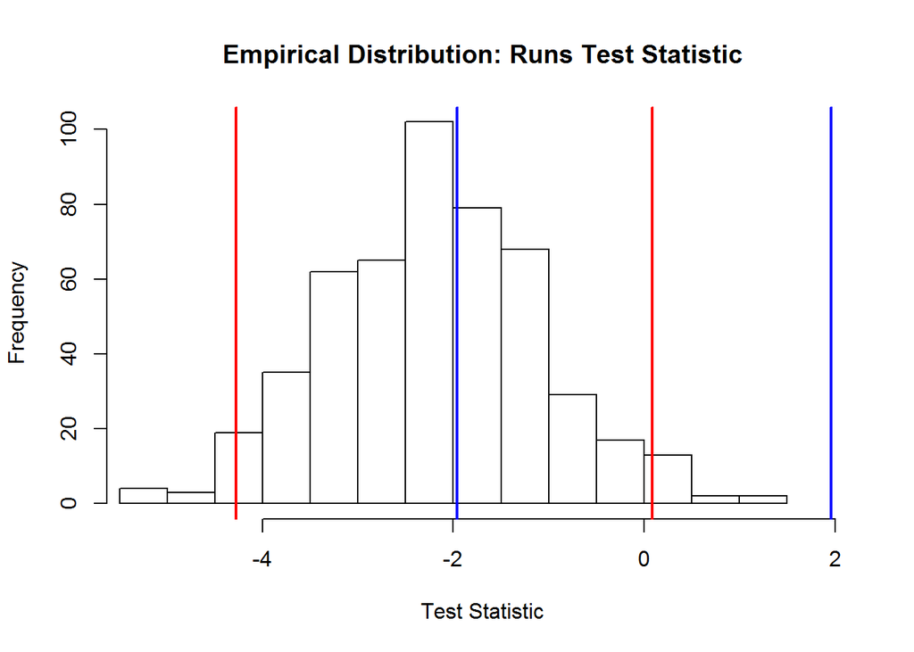

```r
empdistribution<-getRunsCritVals(n.sim = nsim, simData=newdat,
                                 model = fowsim_glm, data = dat, plot=TRUE,
                                 returnDist = TRUE)
```

Use the data generated to assess the 5% error rate for this test when using the Normal distribition or the empirical distribution generated above.

```r
newdat<-generateNoise(nsim, fitted(init_glm), family='poisson', d=1)
ps<-matrix(NA, nrow=nsim, ncol=2)

for(i in 1:nsim){
  sim_glm<-update(fowsim_glm, newdat[,i]~.)
  # find both the empirical and Normal p-values
  ps[i,1]<-runs.test(residuals(sim_glm, type='pearson'), critvals = empdistribution)$p.value
  ps[i,2]<-runs.test(residuals(sim_glm, type='pearson'))$p.value
}
```

```r
(length(which(ps[,1]<0.05))/nsim)*100
```

```
[1] 6.8
```

```r
(length(which(ps[,2]<0.05))/nsim)*100
```

```
[1] 57
```

How does this change if we vary the dispersion parameter for the data?

```r
nphi=seq(1,51, by=5)
errrate<-matrix(NA, nrow=length(nphi), ncol=2)
counter=1
nsim=500
for(p in nphi){
  newdat<-generateNoise(nsim, fitted(init_glm), family='poisson', d=p)
  # for each change in phi, update the empirical distribution
  empdistribution<-getRunsCritVals(n.sim = nsim, simData=newdat,
                                   model = init_glm, data = dat, plot=FALSE,
                                   returnDist = TRUE, dots=FALSE)

  ps<-matrix(NA, nrow=nsim, ncol=2)
  for(i in 1:nsim){
    sim_glm<-update(fowsim_glm, newdat[,i]~.)
    # find both the empirical and Normal p-values
    ps[i,1]<-runs.test(residuals(sim_glm, type='pearson'), critvals = empdistribution)$p.value
    ps[i,2]<-runs.test(residuals(sim_glm, type='pearson'))$p.value
  }

  errrate[counter,1]<-(length(which(ps[,1]<0.05))/nsim)*100
  errrate[counter,2]<-(length(which(ps[,2]<0.05))/nsim)*100
  counter=counter+1
}
```

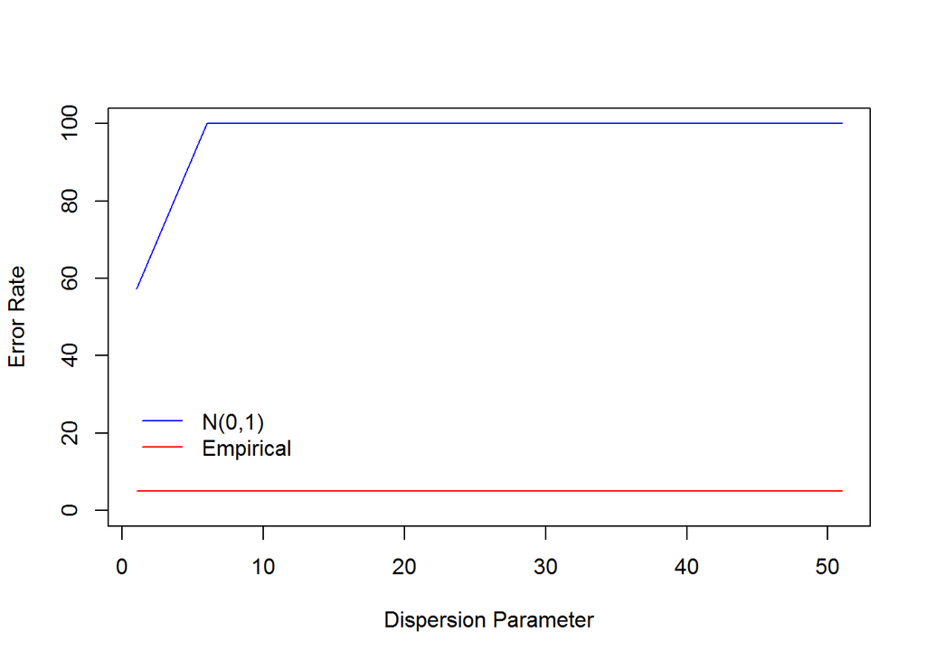

```r
plot(nphi, errrate[,1], type='l', col='red', ylim=c(0, range(errrate)[2]), ylab='Error Rate', xlab='Dispersion Parameter')
lines(nphi, errrate[,2], col='blue')
legend(0, 30, legend = c('N(0,1)', 'Empirical'), col = c('blue', 'red'), lty = c(1,1), bty = 'n')
```